# Static Portfolio

Aleister Montfort

2/17/2019

```r
## COLORS ####
#Source of this and the palette function: https://drsimonj.svbtle.com/creating-corporate-colour-palettes-for-ggplot2

ami_colors <- c(             # I will use these colors
  `red`        = "#ff3333",
  `green`      = "#318333",
  `blue`       = '#2171b5',
  `light_blue`   = '#eff3ff',
  `orange`     = "#e19509",
  `light grey` = "#f7f7f7",
  `dark grey`  = "#808080",
  `peach` = "#FF8C76",
  `pink`= "#F082B3",
  `green2`= "#6da786",
  `green3` = "#4E7F35",
  `blue2`= "#4C64E8",
  `purple`= '#912FF7')

ami_cols <- function(...) { # And create this function to have them ready without typying the HEX Code
  cols <- c(...)
  if (is.null(cols))
    return (ami_colors)
  ami_colors[cols]
}
## Palettes ####
ami_palettes <- list(
  `redish`  = ami_cols('red', 'orange'),

  `cool`  = ami_cols('blue2', 'green2', "orange"),

  `multi`  = ami_cols('red', 'orange', 'green', 'blue', 'grey', 'dark grey'),

  `grey_green`   = ami_cols("dark_grey", "green2"),

  `blue_green` = ami_cols("blue", "green2"),

  `red`  = ami_cols("red"),
  `green_orange`  = ami_cols("green2", "orange"),
  `purple_green2` = ami_cols("green2", "purple"),
  `bluish` = ami_cols("blue", "blue2")

)

## PALETTES####
ami_pal <- function(palette = "cool", reverse = FALSE, ...) {
  pal <- ami_palettes[[palette]]

  if (reverse) pal <- rev(pal)

  colorRampPalette(pal, ...)
}

scale_color_ami <- function(palette = "cool", discrete = TRUE, reverse = FALSE, ...) {

  pal <- ami_pal(palette = palette, reverse = reverse)

  if (discrete) {
    discrete_scale("colour", paste0("ami_", palette), palette = pal, ...)
  } else {
    scale_color_gradientn(colours = pal(256), ...)
  }
}
scale_fill_ami <- function(palette = "main", discrete = TRUE, reverse = FALSE, ...) {
  pal <- ami_pal(palette = palette, reverse = reverse)

  if (discrete) {
    discrete_scale("fill", paste0("ami_", palette), palette = pal, ...)
  } else {
    scale_fill_gradient2(colours = pal(256), ...)
  }
}

##THEMES ####
theme_ami<-
  theme(
  panel.background = element_rect(fill = 'white',
                                colour = ami_cols("light grey"),
                                size = 0.3, linetype = "solid"),
  panel.grid.major = element_line(size = 0.15, linetype = 'solid',
                                colour = ami_cols("light grey")),
  panel.grid.minor = element_line(size = 0.1, linetype = 'solid',
                                colour = "dark grey")) +
  theme(plot.title = element_text(size = 14, family = "Karla", face='bold', hjust=0))+
  theme(plot.subtitle = element_text(size=12, family = "Karla", face = "plain",hjust=0))+
    theme(text=element_text(family="Karla"))+
     theme( axis.text.x=element_text(colour="black", family = "Karla", size = 10, face = "plain"))+
    theme (axis.text.y=element_text(colour="black", family = "Karla", size = 10, face = "plain"))+
        theme(legend.key=element_rect(fill="white", colour="white")) +
  theme(plot.caption = element_text(family="Karla", size=7)) +
  theme(text = element_text(family = "Karla")) +
  theme(line = element_line(color=ami_cols("green")))


theme_amiplots<-
 theme(plot.title = element_text(size = 16, family = "Karla", face='bold', hjust=.5)) +
  theme(plot.subtitle = element_text(size=12, family = "Karla", face = "plain", hjust=0.5)) +
    theme(text=element_text(family="Karla")) +
        theme(legend.key=element_rect(fill="white", colour="white")) +
  theme(plot.caption = element_text(family="Karla", size=7))  +
  theme(legend.title = element_text(face="bold")) +
  theme(legend.background = element_rect()) +
  theme(plot.title = element_text(hjust = 0.5)) +
   theme(legend.background = element_rect(colour = '#00000000', fill = '#00000000'))
```

# 1. Introduction

In a recent [article](https://econ.st/2WuSTSN), the British magazine “The Economist” notes that there is a global decline trend in suicides, mostly driven by China, India and Russia. The article also underlines that America is the big exception: this century, suicides’ rate in America has grown 18%, and if 20 years ago China’s rate doubled America’s, this relationship has been reversed. A similar story can be told about suicides in Mexico.

Compared to the attention that other mortality characteristics receive, this phenomenon has been absent from the public discussion and, to our knowledge, there are no comprehensive studies that account for its characteristics, not to mention its causes. This work focuses on analyzing suicides in Mexico.[^1]

Figure 1 shows the trend in suicides in Mexico since 1998 (green line). To show how the increase in suicides compares to its level in January 1998 and to the growth of other mortality causes, all death rates were set equal to a value of 100 in January 1998. Then the value of this index reflects how much the value of a mortality rate changed as compared to the value of 100 in 1998, and how this growth compares to other mortality growth along the period 1998-2017.

The dramatic increase in homicides, which is arguably the most important policy challenge faced by Mexican authorities, has received special attention in the last 12 years. However, as we may find an exogeous cause that triggered the spiral of violence in the country (namely, the so called “war on drugs”), we don’t find an exact date or cause that points the beginning of the sucides’ upward trend. Nonetheless, we observe a sustained growth since 1998: the ascendant trend in suicides started in the late 1990’s and has kept growing since. This growth has been only surpassed by the increase in the homicides (line in blue), which rate has doubled since 1998, whereas in the case of suicides, the growth is about 50%.

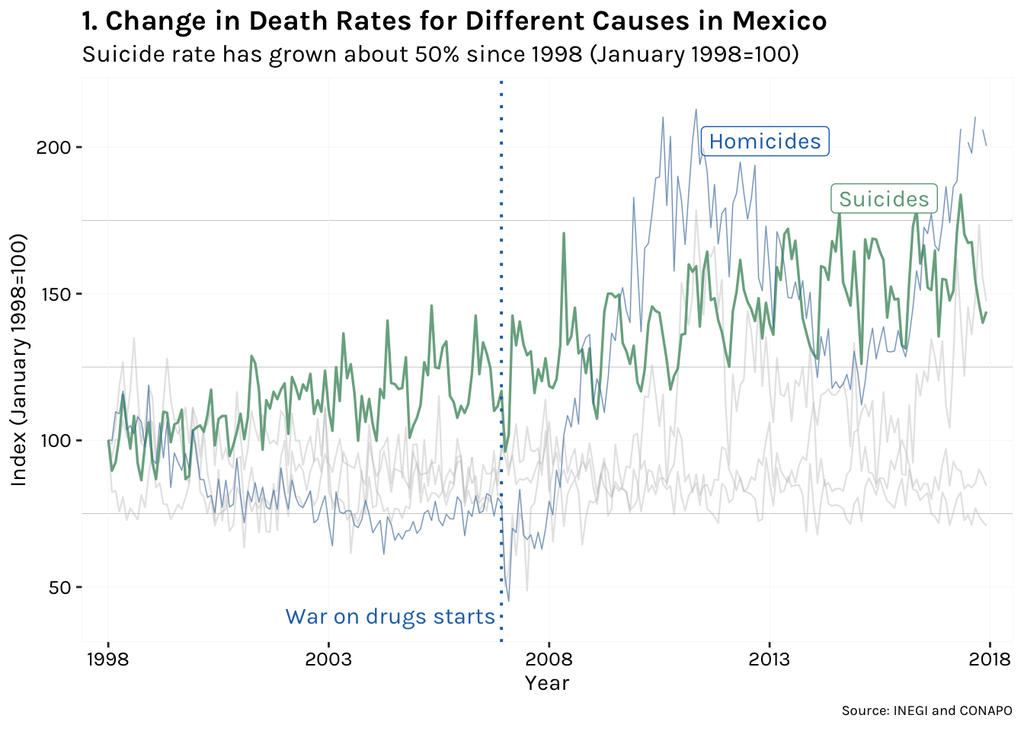

```r
# I do jan 2008 = 100 for each category
deaths_base100<-monthly_death_national %>%
  mutate(index = case_when(non_natural_causes=="Accident" ~ (death_rate*100/4.10),
                           non_natural_causes=="Homicide" ~ (death_rate*100/1.09),
                           non_natural_causes=="Don't know" ~ (death_rate*100/.26),
                           non_natural_causes=="Suicide" ~ (death_rate*100/.286),
                           non_natural_causes=="N.A/Natural Death" ~ (death_rate*100/29.8),
                         non_natural_causes=="War Operations" ~ (death_rate*100/0.00103)))
# I just proved how they looked when plotted each of them
death_filtered <- deaths_base100 %>%
  filter(non_natural_causes=="Suicide")
war_operations_df <- monthly_death_national %>%
  filter(non_natural_causes=="War Operations")
homicides_df <- deaths_base100 %>%
  filter(non_natural_causes=="Homicide")
accidents_df <- deaths_base100 %>%
  filter(non_natural_causes=="Accident")
dn_df <- deaths_base100 %>%
  filter(non_natural_causes=="Don't know")

##PLOT 1 ####
non_natural_plot<-ggplot() +
geom_line(aes(x=yearmonth, y=index, group = non_natural_causes), data = subset(deaths_base100, non_natural_causes!="War Operations"), colour = alpha("grey", 0.4), size=.4) +
  geom_line(aes(x=yearmonth, y=index), data = death_filtered, colour = ami_cols("green2"), alpha=.9, size=.6) +
  geom_line(aes(x=yearmonth, y=index), data = homicides_df, color=ami_cols("blue"),alpha=.6, size=.2) +
 scale_x_discrete(limit = c(1998, 2003, 2008, 2013,  2018)) +
  annotate("label", x = 2012.9, y = 202, label = "Homicides", color=ami_cols("blue"), family="Karla", size=4, alpha=.6) +
  annotate("label", x = 2015.6, y = 182.5, label = "Suicides", color=ami_cols("green2"), family="Karla", size=4) +
  # annotate("segment", x = 2010.2, xend = 2010.6, y = 190, yend = 185.2,
  # colour = ami_cols("blue"))+
  # annotate("segment", x = 2014.6, xend = 2014.7, y = 178, yend = 181,
  # colour = ami_cols("green2"))+
      labs(title = "1. Change in Death Rates for Different Causes in Mexico",
       subtitle = "Suicide rate has grown about 50% since 1998 (January 1998=100)",
       caption = "Source: INEGI and CONAPO",
       x = "Year", y = "Index (January 1998=100)")+
    geom_vline(xintercept =2006.917 , linetype="dotted",
                color = ami_cols("blue"), size=.7)+ ylim(40, 215) +
  geom_text(aes(x=2006.8, label="War on drugs starts", y=40, family="Karla"), size=4, color=ami_cols("blue"), hjust=1) +
  theme_ami
non_natural_plot
```

# 2. Suicides in Mexico

## 2.1 Trends by Age Cohort

Different analysis of suicides have shown that there are important variations across population cohorts. In the case of Mexico, these differences are remarkable. The suicides rate shows the largest increase among the young population: for the 15-35 years old cohort, rate increased from around 6 cases per 100k inhabitants, to a little bit more than 8 in 2017; an increase of about 30%. This growth is also remarkable among the 35-50 cohort, which rose from around 5 to 7 cases per 100k. Among the 50-70 cohort we observe a relatively stable average (though it may seem to exist a seasonality pattern). Finally, in the elder cohort we see a sustained drop in suicides (from around 7 to around 5 cases per 100k).

```r
## DATA FOR COHORTS ####
suicides_by_cohort<-death_certificates[which(death_certificates$non_natural_causes=="Suicide"),]
# Let's re arrange the cohort population dataset#
library(reshape2)
pop_cohort2 <- melt(pop_by_cohort, id=c("cohort"))
colnames(pop_cohort2)[colnames(pop_cohort2)=="variable"] <- "year_merge"
colnames(pop_cohort2)[colnames(pop_cohort2)=="value"] <- "population"
colnames(pop_cohort2)[colnames(pop_cohort2)=="cohort"] <- "age_cohort"
pop_cohort2$year_merge1<-as.numeric(pop_cohort2$year_merge)
pop_cohort2<-pop_cohort2 %>%
  mutate(year_merge1 = case_when(year_merge1==1 ~ 1995,
                                           year_merge1==2 ~ 2000,
                                           year_merge1==3 ~ 2005,
                                           year_merge1==4 ~ 2010,
                                           year_merge1==5 ~ 2015))

pop_cohort2$year_merge <- NULL
colnames(pop_cohort2)[colnames(pop_cohort2)=="year_merge1"] <- "year_merge"

suicides_by_cohort <-suicides_by_cohort %>%  mutate(age_cohort = case_when(age_years<15 ~ 'Less than 15',
                                           age_years>=15 & age_years<35 ~ '15 to 35',
                                           age_years>=35 & age_years<50 ~ '35 to 50',
                                           age_years>=50 & age_years<70 ~ '50 to 70',
                                           age_years>=70 ~ 'More than 70'))

suicides_by_cohort_total <-
  suicides_by_cohort %>%
  group_by(age_cohort, year_death) %>%
  tally()

suicides_by_cohort_total<-suicides_by_cohort_total %>%
  mutate(year_merge = case_when(year_death<2000 ~ 1995,
                                           year_death>=2000 & year_death<=2004 ~ 2000,
                                           year_death>=2005 & year_death<= 2009 ~ 2005,
                                           year_death>=2010 & year_death<= 2015 ~ 2010,
                                           year_death>2015 ~ 2015))

final_suicides_by_cohort <- dplyr:: left_join(suicides_by_cohort_total, pop_cohort2,
                                              by=c("age_cohort"="age_cohort", "year_merge"="year_merge"))

final_suicides_by_cohort<-final_suicides_by_cohort  %>%
   mutate(rate_suicides_bycohort = n/population*100000)

final_suicides_by_cohort$ordered_cohort <- factor(final_suicides_by_cohort$age_cohort, levels = c("Less than 15", "15 to 35", "35 to 50", "50 to 70", "More than 70"))
```

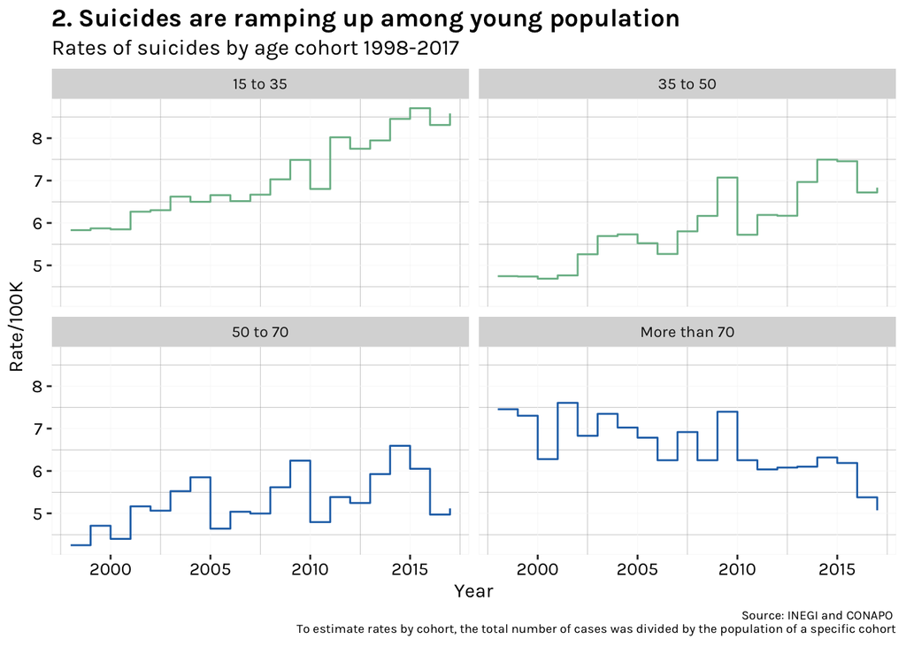

```r
## COHORTS PLOT####
cohortsplot=ggplot(final_suicides_by_cohort %>% filter(!is.na(ordered_cohort) & ordered_cohort!="Less than 15"), aes(x=year_death, y=rate_suicides_bycohort, color=age_cohort)) +
  geom_step() +
  facet_wrap(~ ordered_cohort) +
  ggtitle("2. Suicides are ramping up among young population")+
  labs( subtitle = "Rates of suicides by age cohort 1998-2017",
      caption="Source: INEGI and CONAPO \n To estimate rates by cohort, the total number of cases was divided by the population of a specific cohort" ,x = "Year", y = "Rate/100K") +
  scale_color_manual(values=c("#7ABA95" ,"#7ABA95" ,'#2171b5','#2171b5'), guide=FALSE )+
  scale_alpha_manual(values=c(0.9,0.9,0.6,0.6)) +
  theme_ami
cohortsplot
```

## 2.2 Male and Female Suicides

As relevant as the variation among cohorts, differences between sex are noticeable. From the total cases of suicides since 1998, 82% correspond to male suicides, and 18% to female. The violin plot in Figure 3 analyzes the distribution of ages across males and females who commited suicide. The dotted lines correspond to the percentiles 25th, 50th, and 75th, and the number within the chart corresponds to the average age for each group.

```r
library(ggridges)
suicides_by_sex<- death_certificates %>% select(non_natural_causes,sex, age_years, year_death)

suicides_by_sex <- subset(suicides_by_sex, (non_natural_causes=="Suicide") & (year_death==1998 | year_death==2008 |year_death==2017)  & sex!="Not specified")

stat_sum_df <- function(fun, geom="crossbar", ...) {
  stat_summary(fun.data = fun, colour = "red", geom = geom, width = 0.2, ...)
}
```

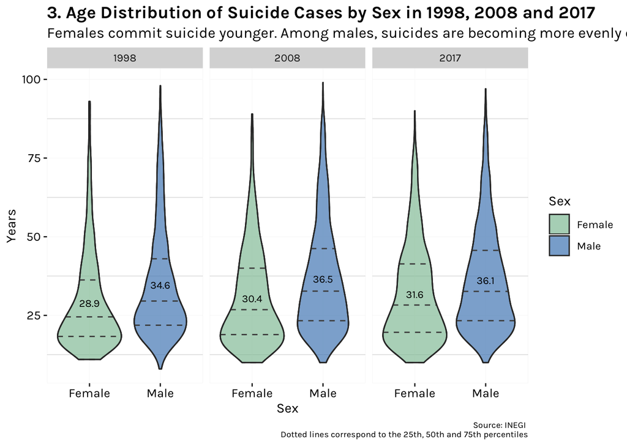

```r
dat_text1 <- data.frame(
  label = c(28.9, 30.4, 31.6),
  year_death   = c(1998, 2008, 2017),
  Sex     = c("Female", "Female", "Female"),
  age_years     = c(28.9, 30.4, 31.6)
)
dat_text2 <- data.frame(
  label = c(34.6, 36.5, 36.1),
  year_death   = c(1998, 2008, 2017),
  Sex     = c("Male", "Male", "Male"),
  age_years     = c(34.6, 36.5, 36.1)
)

colnames(suicides_by_sex)[colnames(suicides_by_sex)=="sex"] <- "Sex"

violines<-ggplot(suicides_by_sex, aes(y=age_years, x=Sex, fill=Sex), alpha=.1) +
  geom_violin(alpha=.6) +
  scale_fill_manual(values=c('#7ABA95', '#2171b5')) +
 geom_violin(draw_quantiles = c(0.25, .5, 0.75), linetype = "dashed",show.legend = FALSE, alpha=0.1)  +
geom_violin(fill= 'transparent', alpha=0.1) +
  facet_wrap(~ year_death) +
geom_text(
  data    = dat_text1,
  mapping = aes(y = age_years, x = Sex,  label = label), size=3, family="Karla") +
geom_text(
  data    = dat_text2,
  mapping = aes(y = age_years, x = Sex,  label = label), size=3, family="Karla")+
  ggtitle("3. Age Distribution of Suicide Cases by Sex in 1998, 2008 and 2017")+
  labs( subtitle = "Females commit suicide younger. Among males, suicides are becoming more evenly distributed in ages 25-40's",
      caption="Source: INEGI \n Dotted lines correspond to the 25th, 50th and 75th percentiles" ,x = "Sex", y = "Years") +
  theme_ami

violines
```

## 2.3 Spatial Distribution of Suicides

Map 1 shows the rate of suicides at the municipal level. The break values used to color the map are the national Mexican average (5.2 cases per 100 thousand inhabitants); the world average (10.5), and the US average (13.7).

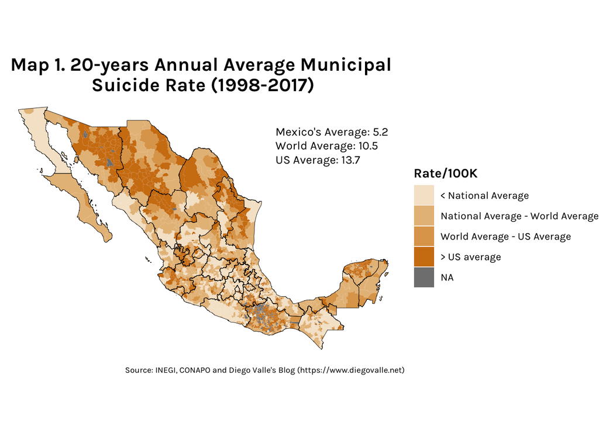

```r
library('rgdal')
library("sf")
library("mxmaps")
library("viridis")
library("scales")
library(reshape2)
k<-100000

### MUNICIPAL SUICIDES ####
library(sf)
mun_shape <- st_read(here::here("Data/muni_2012gw/Muni_2012gw.shp"))
mun_shape<-st_simplify(mun_shape)
suicides_municipal_yearly <-
  filter(death_certificates, non_natural_causes== 'Suicide') %>%
  group_by(state_mun_OCUR, ANIO_OCUR) %>%
  tally()

suicides_municipal_yearly<- merge(x = suicides_municipal_yearly, y = irs, by.x = 'state_mun_OCUR', by.y ='municipal_id' )

suicides_municipal_yearly<-  select (suicides_municipal_yearly,c(state_mun_OCUR, "ANIO_OCUR", "n", "cve_edo","state_name",  "municipal_name", "pop2000", "pop2005", "pop2010", "pop2015"))


suicides_municipal_yearly<- suicides_municipal_yearly %>%
  mutate(rate= case_when(ANIO_OCUR<=2002 ~ n/(as.numeric(pop2000))*k,    ANIO_OCUR>2002 & ANIO_OCUR<=2008 ~ (n/as.numeric(pop2005))*k,
                                          ANIO_OCUR>2008 & ANIO_OCUR<= 2013 ~ (n/as.numeric(pop2010))*k,
                                          ANIO_OCUR>2013 ~ (n/as.numeric(pop2015))*k), na.rm = TRUE)

municipal_average_suicide<-suicides_municipal_yearly%>%
  group_by(state_mun_OCUR, municipal_name, cve_edo, state_name) %>%
  summarise_at(c("rate"), funs(mean(., na.rm=TRUE)))

mun_shape<- mun_shape %>%
    mutate(state_mun_OCUR= paste(CVE_ENT, CVE_MUN, sep=""))

mun_shape = mun_shape %>%
    left_join(municipal_average_suicide, by = "state_mun_OCUR")

mun_shape<- mun_shape %>%
  mutate(rate_cut = cut(mun_shape$rate, c(0,5.2,10.5,13.7,356)))

colnames(mun_shape)[colnames(mun_shape) == 'state_mun_OCUR'] <- 'region'
#colnames(mun_shape)[colnames(mun_shape) == 'rate_cut'] <- 'value'

mun_shape<- mun_shape %>% mutate(
  value_label=case_when(rate_cut=="(0,5.2]" ~ "< National Average",
                 rate_cut=="(5.2,10.5]" ~ "National Average - World Average",
                 rate_cut=="(10.5,13.7]" ~ "World Average - US Average",
                 rate_cut=="(13.7,356]" ~ "> US average"))
colnames(mun_shape)[colnames(mun_shape) == 'value'] <- 'interval'
mun_shape$value_label <- factor(mun_shape$value_label, levels = c( "< National Average","National Average - World Average", "World Average - US Average", "> US average"))
colnames(mun_shape)[colnames(mun_shape) == 'value_label'] <- 'value'


municipal_suicides_plot<-mxmunicipio_choropleth(mun_shape)+ scale_fill_manual("Rate/100K", values=c('#f5e5cf','#e7be88', '#dea459', '#d07e12'), na.value=ami_cols("dark grey"))  +
  scale_alpha_manual(values=c(0.8,0.8,0.8,0.8)) +
  labs(title = "Map 1. 20-years Annual Average Municipal \nSuicide Rate (1998-2017)",
       legend = "Rate (#/100K)",
       caption = "Source: INEGI, CONAPO and Diego Valle's Blog (https://www.diegovalle.net) ") +
  annotate(geom = "text", x = -96, y = 31, label = "Mexico's Average: 5.2", size = 3.5, hjust = 0, family="Karla") + annotate(geom = "text", x = -96, y = 30, label = "World Average: 10.5", size = 3.5, hjust = 0, family="Karla") + annotate(geom = "text", x = -96, y = 29, label = "US Average: 13.7", size = 3.5, hjust = 0, family="Karla") +
  theme_amiplots
municipal_suicides_plot[["layers"]][[1]][["aes_params"]][["colour"]] <- "transparent"
municipal_suicides_plot
```

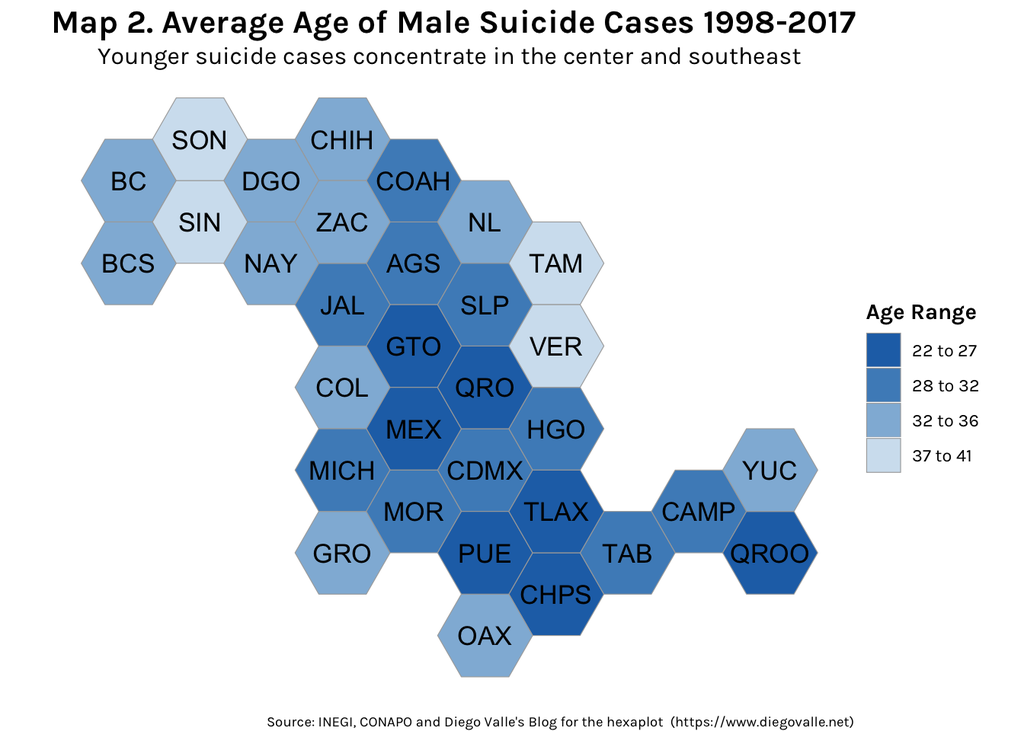

```r
library('rgdal')
library("sf")
library("mxmaps")
library("viridis")
library("scales")
library("reshape2")
k<-100000

## Age States Suicides ####
state_shape<- st_read(here::here("data/state_boundaries/dest_2015gw/dest_2015gw.shp"))
state_shape<-st_simplify(state_shape)

suicides_state_yearly <-
  filter(death_certificates, non_natural_causes== 'Suicide') %>%
  group_by(state_ocur, ANIO_OCUR) %>%
  tally()

state_population<- irs %>%
  group_by(cve_edo) %>%
  summarize(tot00 = sum(pop2000, na.rm = TRUE),
            tot05 = sum(pop2005, na.rm = TRUE),
            tot10=sum(pop2010, na.rm=TRUE),
            tot15=sum(pop2015, na.rm=TRUE))

## Have to do this because there is no single ID (as compared to municipal data)
suicides_state_yearly<-suicides_state_yearly %>%
  mutate(year_merge = case_when(ANIO_OCUR<2000 ~ "tot00",
                                           ANIO_OCUR>=2000 & ANIO_OCUR<=2004 ~ "tot00",
                                           ANIO_OCUR>=2005 & ANIO_OCUR<= 2009 ~ "tot05",
                                           ANIO_OCUR>=2010 & ANIO_OCUR<= 2015 ~ "tot10",
                                           ANIO_OCUR>2015 ~ "tot15"))
state_population<-melt(state_population, id=c("cve_edo"))

##THIS IS ONLY FOR AGE PLOTS####
suicides_state_age_by_sex<-
  filter(death_certificates, non_natural_causes== 'Suicide' & (sex=="Male" | sex=="Female")) %>%
  group_by(state_ocur, sex) %>%
  dplyr::summarize(Mean = mean(age_years, na.rm=TRUE))

male_state_suicides<-dplyr:: left_join(state_shape, subset(suicides_state_age_by_sex,sex=="Male"),  by= c('CVE_ENT'="state_ocur"))

female_state_suicides<-dplyr:: left_join(state_shape, subset(suicides_state_age_by_sex,sex=="Female"), by= c( 'CVE_ENT'="state_ocur"))

male_state_suicides$value<-cut(male_state_suicides$Mean, 4, labels=c("22 to 27", "28 to 32" , "32 to 36", "37 to 41"))
colnames(male_state_suicides)[colnames(male_state_suicides)=="CVE_ENT"] <- "region"

female_state_suicides$value<-cut(female_state_suicides$Mean, 4, labels=c("27 to 29", "30 to 31" , "32 to 33", "33 to 35"))
colnames(female_state_suicides)[colnames(female_state_suicides)=="CVE_ENT"] <- "region"

male_state_suicide_plot<- mxhexbin_choropleth(male_state_suicides, num_colors = 4) +
 labs(title = " Map 2. Average Age of Male Suicide Cases 1998-2017",
       subtitle = "Younger suicide cases concentrate in the center and southeast",
      legend = "Age",
       caption = "Source: INEGI, CONAPO and Diego Valle's Blog for the hexaplot  (https://www.diegovalle.net)") + scale_fill_manual("Age Range", values=c('#2171b5',
'#4d8dc3',
'#90b8da',
'#d2e2f0'
))  +
theme_amiplots

male_state_suicide_plot
```

These two maps suggest that the states at the center and south east of the country concentrate most of the cases of young suicides, but not necessarily the higher rates.

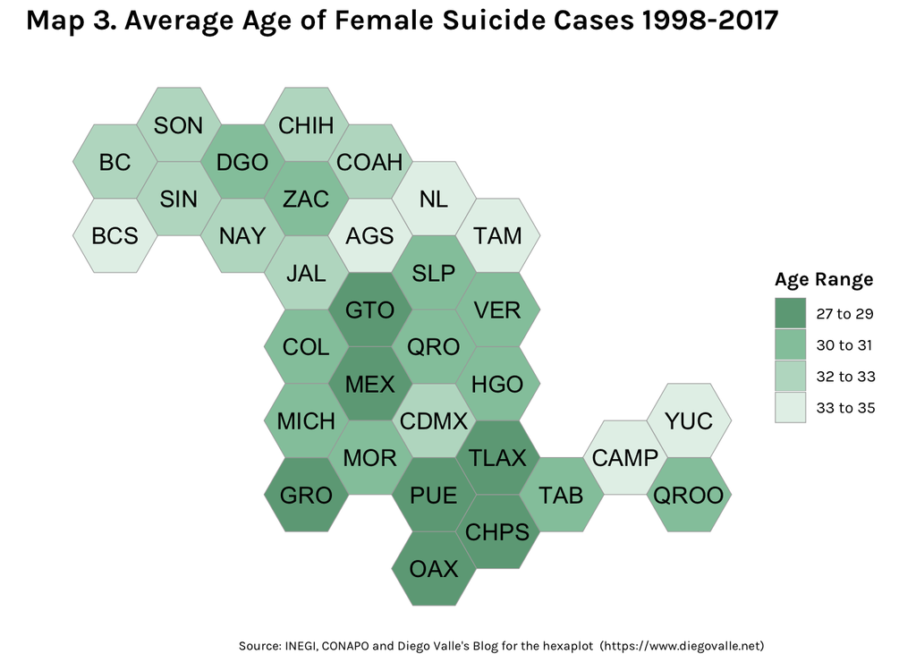

```r
library('rgdal')
library("sf")
library("mxmaps")
library("viridis")
library("scales")
library('reshape2')
k<-100000

female_state_suicide_plot<- mxhexbin_choropleth(female_state_suicides, num_colors = 4) +
 labs(title = "Map 3. Average Age of Female Suicide Cases 1998-2017",
       subtitle = "",
      legend = "Age",
       caption = "Source: INEGI, CONAPO and Diego Valle's Blog for the hexaplot  (https://www.diegovalle.net)") + scale_fill_manual("Age Range", values=c('#6da786',
'#94c7aa',
'#bcdcca',
'#e4f1e9'
)) +
theme_amiplots
female_state_suicide_plot
```

## 2.4 Suicides and Occupation

Chart 4 shows the distribution of suicide cases by occupation and age for the population between 25 and 50 years old. A special interest to show this chart is the analysis of how unemployment may be associated with suicide cases.

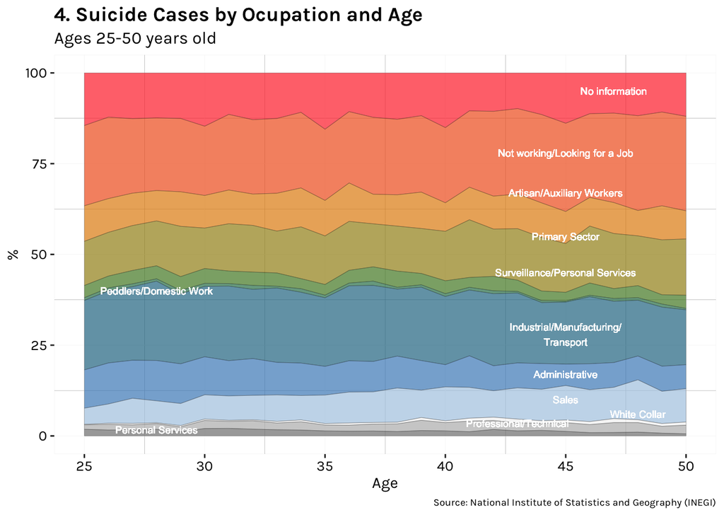

```r
suicides_occupation<- death_certificates %>% select(non_natural_causes,sex,school_category, occupation, age_years)

suicides_occupation_male <- filter(suicides_occupation, non_natural_causes=="Suicide" & age_years>=25 & age_years<=50)

suicides_occupation_male = suicides_occupation_male %>%
                              mutate(occupation =                                        if_else(occupation=='55',"Industrial/Manufacturing/Transport worker", occupation))
suicides_occupation_male = suicides_occupation_male %>%
                              mutate(occupation =                                        if_else(occupation=="Looking for Job" | occupation=='Not Working',"Not Working/Looking for a job", occupation))

suicides_occupation_male = suicides_occupation_male %>%
                              mutate(occupation =                                        if_else(occupation=="Informal seller (Vend. Amb)"| occupation=="Domestic/House Services","Informal Worker", occupation))

normalized_suic_age_male<- suicides_occupation_male %>%
  group_by(age_years, occupation) %>%
  tally() %>%
group_by(age_years) %>% mutate(percent = n/sum(n)*100)

normalized_suic_age_male$ordered_vars <- factor(normalized_suic_age_male$occupation, levels=c("NA", "Not Working/Looking for a job", "Artisan/Auxiliary Workers", "Primary Sector Worker", "Surveillance-Personal Services", "Informal Worker", "Industrial/Manufacturing/Transport worker", "Admin Work", "Salesman", "White Collar", "Professional-Technical worker", "Personal Services at businesses" ))

size_parameter<-2.5
occupation_plot<-ggplot(normalized_suic_age_male, aes(x=age_years, y=percent, fill=ordered_vars)) +
  geom_area(size=.05, alpha=.7, color='black' , show.legend = FALSE) +
scale_fill_manual(values=ami_pal("multi")(12)) +
    geom_text(aes(x=47, label="No information", y=95), colour="white", size=size_parameter) +
    geom_text(aes(x=45, label="Not working/Looking for a Job", y=78), colour="white", size=size_parameter) +
    geom_text(aes(x=45, label="Artisan/Auxiliary Workers", y=67), colour="white", size=size_parameter) +
    geom_text(aes(x=45, label="Primary Sector", y=55), colour="white", size=size_parameter) +
    geom_text(aes(x=45, label="Surveillance/Personal Services", y=45), colour="white", size=size_parameter) +
    geom_text(aes(x=28, label="Peddlers/Domestic Work", y=40), colour="white", size=size_parameter) +
    geom_text(aes(x=45, label="Industrial/Manufacturing/\nTransport", y=28), colour="white", size=size_parameter) +
    geom_text(aes(x=45, label="Administrative", y=17), colour="white", size=size_parameter) +
    geom_text(aes(x=45, label="Sales", y=10), colour="white", size=size_parameter) +
    geom_text(aes(x=48, label="White Collar", y=6), colour="white", size=size_parameter) +
    geom_text(aes(x=43, label="Professional/Technical", y=3.5), colour="white", size=size_parameter) +
    geom_text(aes(x=28, label="Personal Services", y=1.75), colour="white", size=size_parameter) +
  labs(title = "4. Suicide Cases by Ocupation and Age",
       subtitle="Ages 25-50 years old",
       caption = "Source: National Institute of Statistics and Geography (INEGI)",
       x = "Age", y = "%") +
       theme(plot.title = element_text(lineheight=.8, face="bold")) +
theme_ami
occupation_plot
```

## 2.5 Time Patterns

The heatmaps below analyze the temporal pattern of suicides occurence. Time and day are an important characteristic of the suicides phenomenon, and an intervention aimed to prevent suicides should consider when suicides are more likely to occur.

Chart 5 shows the time patterns for male and female suicide cases. Whereas for males the likelihood of suicide occurence is greater during the weekends (the horizontal blocks for Sunday and Monday), and in any day around midnight (the vertical line on zero), these patterns are still present in the female case, but with a more homogenous distribution during the weekdays. [^2]

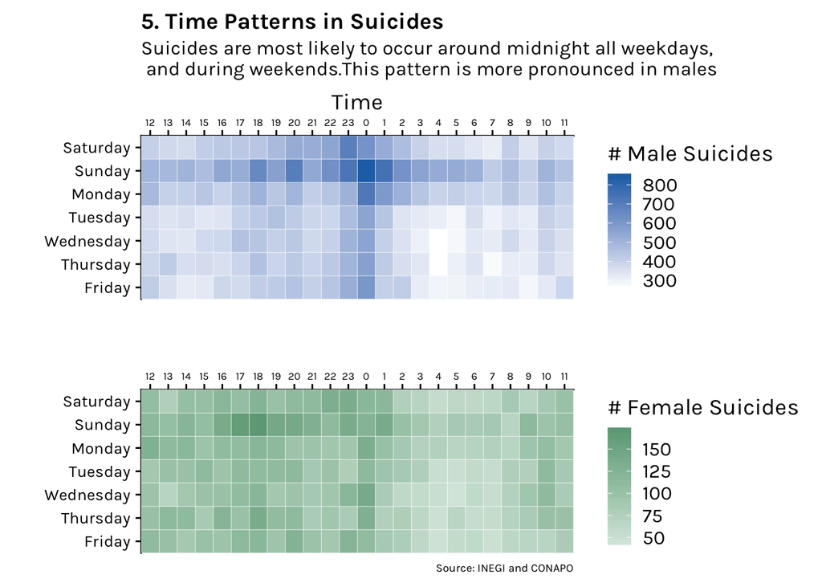

```r
## Suicide time heatmap####
library(lubridate)
library(ggpubr)
library(cowplot)
library(egg)

daily_suicides<-death_certificates[which(death_certificates$non_natural_causes=="Suicide"),]
daily_suicides <-  daily_suicides  %>%
  mutate(day_of_suicide=weekdays(as.Date(date_death)))

daily_suicides$numeric_time<- as.POSIXct(daily_suicides$time_death, format = "%H:%M:%S")
daily_suicides$hour_suicide <- hour(daily_suicides$numeric_time)

test_suicides <-
  daily_suicides %>%
  group_by(hour_suicide, day_of_suicide, sex) %>%
  tally()

test_suicides$day_of_suicide <- factor(test_suicides$day_of_suicide, levels = c( "Friday","Thursday", "Wednesday", "Tuesday",  "Monday",  "Sunday", "Saturday" ))
#c("Monday", "Tuesday", "Wednesday", "Thursday", "Friday", "Saturday", "Sunday"))

test_suicides <- test_suicides %>%
              mutate(hour_factor=as.factor(hour_suicide))
test_suicides$hour_factor <- factor(test_suicides$hour_suicide, levels = c(  "12","13", "14","15", "16","17",'18','19','20','21','22','23','0','1','2','3','4','5','6','7','8','9','10','11'))
#c("Monday", "Tuesday", "Wednesday", "Thursday", "Friday", "Saturday", "Sunday"))

## Male Plot ####
heat_map_suicide_male <- ggplot(test_suicides %>% filter(!is.na(day_of_suicide) & !is.na(hour_suicide) & sex=='Male'), aes(hour_factor, day_of_suicide,  fill=n)) +
 geom_tile(aes(fill = n), color="white") +
      scale_fill_gradient(low = "white", high = ami_cols('blue')) + #scale_x_discrete(position = "top")+
    scale_x_discrete(position = "top", breaks=test_suicides$hour_factor, expand=c(0,0)) +
   scale_y_discrete(breaks=test_suicides$day_of_suicide, expand=c(0,0)) +

  ggtitle("5. Time Patterns in Suicides")+
  labs( subtitle = "Suicides are most likely to occur around midnight all weekdays,\n and during weekends.This pattern is more pronounced in males",
      caption="" ,x = "Time", y="") +
  labs(fill = "# Male Suicides") +
  theme_ami +
  theme(axis.text.x=element_text(size=6.5))

## Female Plot ####

heat_map_suicide_female <- ggplot(test_suicides %>% filter(!is.na(day_of_suicide) & !is.na(hour_suicide) & sex=="Female"), aes(hour_factor, day_of_suicide,  fill=n)) +
 geom_tile(aes(fill = n), color="white") +
    scale_fill_gradient2 (low = "white", high = ami_cols('green2'))  +
    scale_x_discrete(position = "top", breaks=test_suicides$hour_factor,expand=c(0,0)) +
   scale_y_discrete(breaks=test_suicides$day_of_suicide, expand=c(0,0)) +

  labs( #subtitle = "Average rate of growth 1999-2017",
      caption="Source: INEGI and CONAPO" ,x = "", y="") +
  labs(fill = "# Female Suicides") +
   theme_ami +
  theme(axis.text.x=element_text(size=6.5))
## Both Plots ####
heatmaps<-egg::ggarrange(heat_map_suicide_male, heat_map_suicide_female, ncol=1)
```

## 2.6 Chihuahua and Yucatan States Comparison

To analyze some of the characteristics of the states with the larger suicides rates, treemaps were created to show simmilarities and contrasts between the national characteristics of suicide population, and those of Yucatan and Chihuahua states.

Regarding age and sex structure of suicide population (Figure 6A), both Chihuahua and Yucatan show a similar structure as the national one. However, in Chihuahua we observe more suicides in male older cohorts as compared to the whole country and Yucatan.

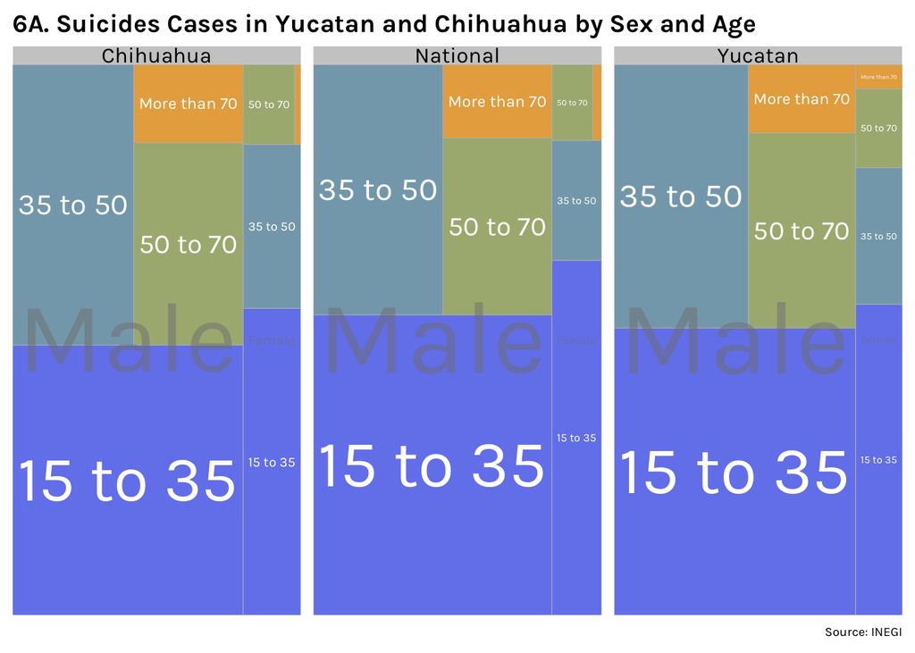

```r
library(treemapify)
library(treemap)
#age_years<15 ~ 'Less than 15',
suicides_yuc <-
  filter(death_certificates, non_natural_causes== 'Suicide' &age_years>=15)
suicides_yuc <-suicides_yuc %>%  mutate(age_cohort = case_when(
                                           age_years>=15 & age_years<35 ~ '15 to 35',
                                           age_years>=35 & age_years<50 ~ '35 to 50',
                                           age_years>=50 & age_years<70 ~ '50 to 70',
                                           age_years>=70 ~ 'More than 70'))

suicides_yuc = suicides_yuc %>%
                              mutate(occupation =                                        if_else(occupation=='55',"Industrial/Manufacturing/Transport worker", occupation))
suicides_yuc= suicides_yuc %>%
                              mutate(occupation =                                        if_else(occupation=="Looking for Job" | occupation=='Not Working',"Not Working/Looking for a job", occupation))

suicides_yuc = suicides_yuc%>%
                              mutate(marital_status =                                        if_else(marital_status=="free_union","Cohabiting unmarried", marital_status))

suicides_yuc = suicides_yuc %>%
                              mutate(marital_status =                                        if_else(marital_status=="divorced" | marital_status=="separated","Divorced/Separated", marital_status))


suicides_yuc= suicides_yuc %>%
                              mutate(state =                                        if_else(ENT_OCURR=="31","Yucatan", if_else(ENT_OCURR=="08","Chihuahua", "National")))

cohort_suicides_yuc<-
  suicides_yuc %>%
  group_by(age_cohort, sex, state) %>%
  tally()
occup_suicides_yuc<-
  subset(suicides_yuc, age_years>25 & age_years<65) %>%
  group_by(occupation, state) %>%
  tally()
educ_suicides_yuc<-
  subset(suicides_yuc, age_years>25) %>%
  group_by(school_category, state) %>%
  tally()
marital_suicides_yuc<-
  subset(suicides_yuc, age_years>18) %>%
  group_by(marital_status, state) %>%
  tally()

## Plots ####
palette_cohort_treemap<- c("#4C64E8", "#6190A6", "#93A15C", "#E19509")
treemap_cohorts<-ggplot(subset(cohort_suicides_yuc, sex!="Not specified" ), aes(area = n, subgroup=sex, fill=age_cohort, label = age_cohort)) +
  geom_treemap( alpha=0.8, palette=ami_pal("cool")(4)) +
  geom_treemap_text( colour = "white", place = "centre",
                    grow = TRUE, family="Karla", min.size = 0, palette=ami_pal("cool")(4)) +
  geom_treemap_subgroup_text(place = "centre", grow = T, alpha = 0.5, colour =
                             ami_cols("dark grey"), min.size = 0, family="Karla") +

  facet_wrap( ~state) +
    theme(legend.position="bottom") + guides(fill=FALSE) +
  labs(title = "6A. Suicides Cases in Yucatan and Chihuahua by Sex and Age",
        caption = "Source: INEGI") +
    scale_fill_manual(values=palette_cohort_treemap, aesthetics = "fill") +
  theme_ami
treemap_cohorts
```

```r
palette_occup_treemap<- c("#4C64E8", "#516FD7", "#577AC7", "#5C85B7", "#6190A6", "#679B96", "#6DA786", "#80A471", "#93A15C", "#A79E47","#BA9B32", "#CD981D", "#E19509")
treemap_occupation<-ggplot(subset(occup_suicides_yuc, occupation!="NA"), aes(area = n, fill=occupation, label = occupation)) +
  geom_treemap() +
  geom_treemap_text( colour = "white", place = "centre",
                    grow = TRUE, min.size=0)  +
  facet_wrap( ~state) + guides(fill=FALSE) +
    scale_fill_manual(values=palette_occup_treemap, aesthetics = "fill")
  labs(title = "6B. Suicides Cases in Yucatan and Chihuahua by Occupation",
       subtitle="Population between 25 and 65 years old",
       caption = "Source: INEGI") +
theme_amiplots


palette_school_treemap<-c("#4C64E8", "#597EC0", "#669999", "#84A36C", "#B29C3A", "#E19509")
treemap_school<-ggplot(subset(educ_suicides_yuc, school_category!="NA"), aes(area = n, fill=school_category, label = school_category)) +
  geom_treemap() +
  geom_treemap_text( colour = "white", place = "centre",
                    grow = TRUE, min.size = 0) + facet_wrap( ~state) +
    theme(legend.position="bottom") + guides(fill=FALSE)+
    scale_fill_manual(values=palette_school_treemap, aesthetics = "fill")+
  labs(title = "6C. Suicides Cases in Yucatan and Chihuahua by School Category",
       subtitle="Population older than 25",
       caption = "Source: INEGI") +
theme_amiplots


palette_marital_treemap<-c("#4C64E8", "#5C85B7", "#6DA786", "#A79E47", "#E19509")
treemap_marital<-ggplot(subset(marital_suicides_yuc, marital_status!="NA"), aes(area = n, fill=marital_status, label = marital_status)) +
  geom_treemap() +
  geom_treemap_text( colour = "white", place = "centre",
                    grow = TRUE, family="Karla", min.size = 0) + facet_wrap( ~state) +
     guides(fill=FALSE)+
   scale_fill_manual(values=palette_marital_treemap, aesthetics = "fill")+
  labs(title = "6D. Suicides Cases in Yucatan and Chihuahua by Marital Status",
       subtitle="Population older than 18",
       caption = "Source: INEGI") +

theme_amiplots
```

Figure 6B shows the breakdown by occupation. The first thing to note is the size of unemployed people share, which is the largest in the three cases. Interestingly, Chihuahua, a state which economy relies heavily on the manufacturing industry (and the share of the employed population in this sector is among the top in the country), shows a smaller share of this category as compared to the national level, which suggests that the distribution of occupations among suicide cases does not necessarily follow the distribution of occupations in a geographic unit, and some employment regional characteristics maybe important to characterize this population.In the state of Yucatan, the share of administrative workers is larger than the national level and Chihuahua. The same situation occurs for the Artisan/Auxiliary workers category in the state of Chihuahua.

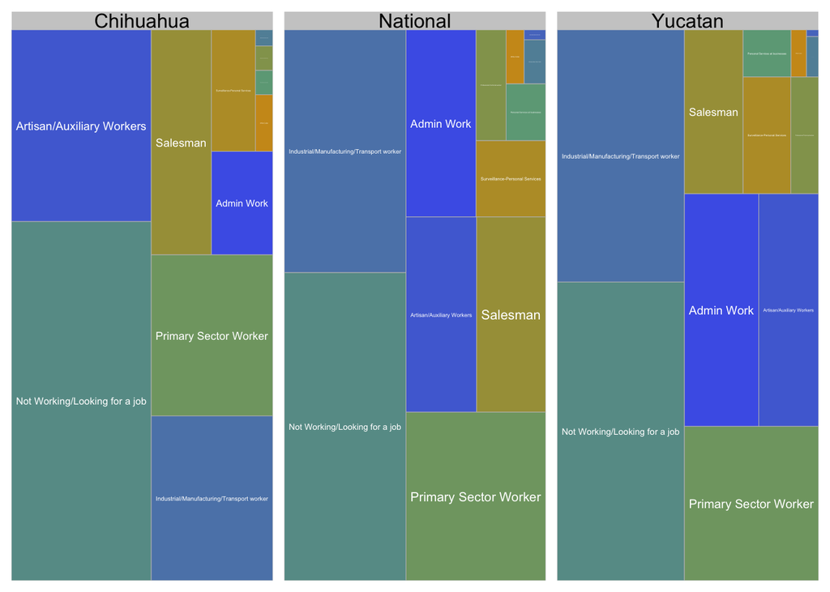

We also analyze the schooling degree of suicide population as a proxy of economic status. To avoid a bias of young suicide population that did not complete highschool or college, we subset the data to the population older than 25 years old. When we take a look at the school levels of suicide population, we observe at the national level that a majority has, at most, only complete elementary school, and only a minority of the suicide population completed a professional degree (licenciatura), which corresponds to the upper-right orange rectangle. As in the case of homicides, suicides affect relatively more young, male, unschooled population.

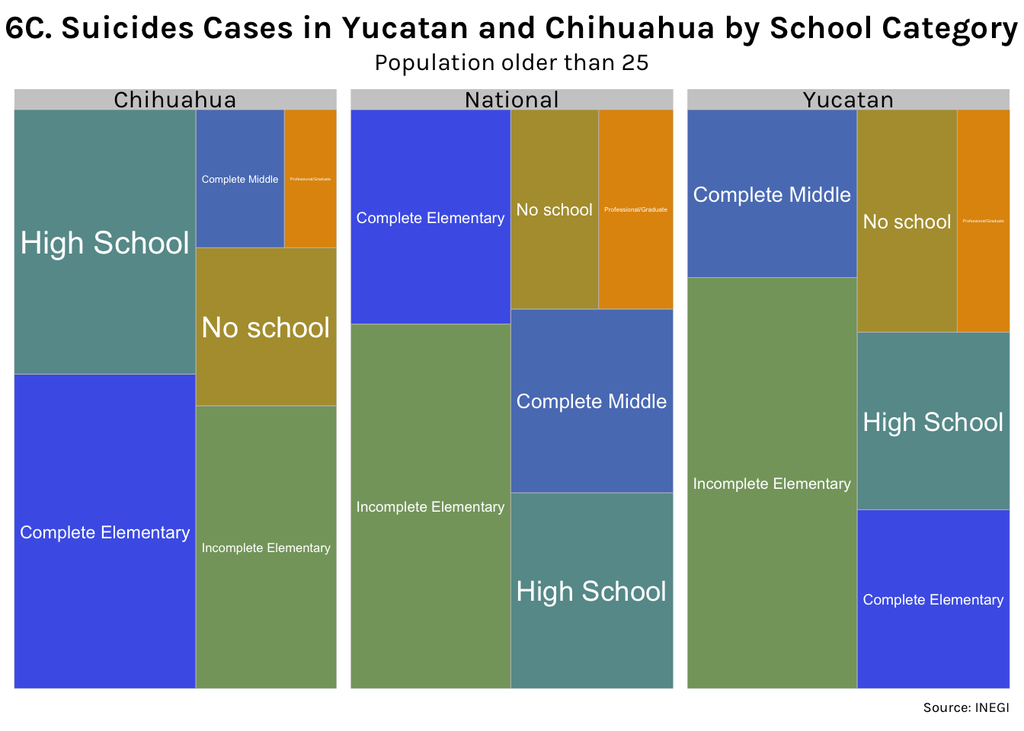

[^1]: I thank Alex Engler, Cory Rand and Sinclair Target for their insightful comments to improve this work. The contents, design and mistakes are my own.
[^2]: Note that the scales are different